# TASK (dataset: preterm)

Amanda Wittendorf

2026-10-05

## 1. DESKRIPTION ON THE DATASET

The dataset is from the pack `statistisk` and contains measurements gestational age in whole weeks. More specifically:

- $\text{gestage}$: gestational age in whole weeks
- $\text{age}$: Maternal age (year)
- $\text{parity}$: The number of which a mother has given birth; primiparous is defined as a first time mother while multiparous is defined as women who have given birth before (primipara / multipara)
- $\text{year}$: Year of birth
- $\text{smoker}$: mothers smoking status (Yes / No)
- $\text{preterm}$: preterm birth (Yes / No)
- $\text{sex}$: gender (1 = male, 2 = female)
- $\text{paritygrp}$: Categorization of the variable parity
- $\text{age30}$: Maternal age, centered at 30 year old (year)

## 2. MULTIPLE LOGISTIC REGRESSION MODEL

The purpose of this section is to evaluate what happens when using a factor as an outcome. When doing so `glm()` treats the first category as a ‘non-event’ and the remaining categories as an ‘event’. It is therefore important to know and choose the relevant event of its factor

To construct a model for the odds of preterm birth it’s important to set the output-reference correct:

- *Yes:* Odds of full-term / non-preterm birth
- *No:* Odds of preterm birth

Therefore, *the correct reference is no*.

### 2.1. ASSOCIATION BETWEEN PRETERM BIRTH AND MATERNAL AGE ADJUSTED FOR PARITY, SMOKE STATUS AND GENDER.

**The model**
$$\text{preterm} = \beta_\text{0} + \beta_\text{1}
\cdot \text{age} + \beta_\text{2} \cdot \text{paritygrp} +
\beta_\text{3} \cdot \text{smoker} + \beta_\text{4} \cdot
\text{sex}$$

**Table 1: Association between preterm birth and maternal age adjusted for parity, smoker status and gender**

|  | *Dependent variable:* |  |
| --- | --- | --- |
|  | preterm |  |
|  | (1) | (2) |
| Maternal age (year) | 1.01 |  |
|  | (0.99, 1.04) |  |
| Centeret maternal age (30 year) |  | 1.01 |
|  |  | (0.99, 1.04) |
| Nulliparaous (no children) | 1.48** | 1.48** |
|  | (1.17, 1.88) | (1.17, 1.88) |
| Multiparaous (>=2) | 1.03 | 1.03 |
|  | (0.73, 1.43) | (0.73, 1.43) |
| Smoker (ref. = No) | 1.79*** | 1.79*** |
|  | (1.45, 2.20) | (1.45, 2.20) |
| Gender (ref. = Boy) | 0.88 | 0.88 |
|  | (0.72, 1.08) | (0.72, 1.08) |
| Intercept | 0.02*** | 0.03*** |
|  | (0.01, 0.04) | (0.02, 0.04) |
| Observations | 10,509 | 10,509 |
| *Note:* | p<0.05; p<0.01; p<0.001 |  |
|  | Preterm birth (ref. = no); Maternal age (year); Parity (ref. = primiparous); Smoker status (ref. = no); Gender (ref. = Boy) |  |

**INTREPETATION**

The difference between the two models are, that (1) contains non-centeret maternal age, and (2) contains maternal age centeret at 30 years of age. Table 1 shows, that the estimates don’t change when centering the variable.

One of the reasons why this happens may be do to the fact, that the dataset includes information on nulliparaous women. These don’t have a maternal age and therefore their value at this parameter is NA.

**Reference group:** Represents a non-smoking, primiparous woman (1 previous child) with a baseline maternal age of 0 years, who gives birth to a non-pretermed boy.

**Intercept:** The statistically significant odds for having preterm birth ($\text{ptd}$) for the reference group - this is not of biological meaning because of the maternal age.

**Interpretation of the rest of the variables:** Same as above…

#### 2.1.1. Categorized maternal age

As seen above, the maternal age, centeret or not, was found to be non-significant as a continues variable in the association. Therefore, it makes sense to check how the effect of the maternal age changes when included as a categorized variable instead of the continues one. A histogram is constructed to evalute the distribution of the variable and thereby determined the right categotization of it:

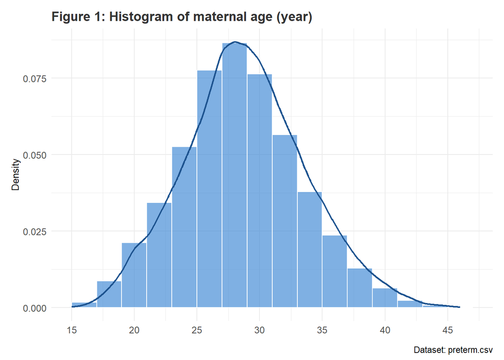

Table 2: Distribution of maternal age categories

| Parameter | count (n) |
| --- | --- |
| <25 | 3075 |
| 25-30 | 5307 |
| 30-35 | 3375 |
| 35-40 | 1052 |
| >40 | 143 |

**INTERPRETATION**

The histogram shows two things:

1. The distribution of the maternal age (year) is normal distributed
2. A categorization of the intervals `<25; 25-30; 30-35; 35-40; >40` do so that all parameters contain more than 10 events.

Now, a new regression analysis can be made to see, if the categorization changes the significans:

**Table 3: Comparing two models to examin how maternal age affects the association (continuert vs. categorized)**

|  | *Dependent variable:* |  |
| --- | --- | --- |
|  | preterm |  |
|  | (1) | (2) |
| Maternal age (year) | 1.01 |  |
|  | (0.99, 1.04) |  |
| Maternal age (<25) |  | 0.92 |
|  |  | (0.71, 1.19) |
| Maternal age (30-35) |  | 0.89 |
|  |  | (0.66, 1.20) |
| Maternal age (35-40) |  | 1.48* |
|  |  | (0.99, 2.18) |
| Maternal age (>40) |  | 1.10 |
|  |  | (0.33, 2.73) |
| Nulliparaous (no children) | 1.48** | 1.43** |
|  | (1.17, 1.88) | (1.13, 1.82) |
| Multiparaous (>=2) | 1.03 | 0.99 |
|  | (0.73, 1.43) | (0.70, 1.38) |
| Smoker (ref. = No) | 1.79*** | 1.75*** |
|  | (1.45, 2.20) | (1.41, 2.15) |
| Gender (ref. = Boy) | 0.88 | 0.88 |
|  | (0.72, 1.08) | (0.72, 1.08) |
| Intercept | 0.02*** | 0.03*** |
|  | (0.01, 0.04) | (0.02, 0.04) |
| Observations | 10,509 | 10,509 |
| *Note:* | p<0.05; p<0.01; p<0.001 |  |
|  | Preterm birth (ref. = no); Maternal age (ref. = 25-30); Parity (ref. = Primiparous); Smoker status (ref. = No); Gender (ref. = Boy) |  |

**INTERPRETATION**

When comparing all other variables adjusted for in the association non-significant change is to be noted.